# Is our selection process biased? A fairness audit

UC Berkeley graduate admissions, fall 1973 (4,526 applications)

Author

Alexis Yipmo

Published

October 3, 2026

**Setup: paths, seed, functions, plot theme**

```r
set.seed(42)  # no random step in this audit; fixed for reproducibility of any extension

find_root <- function(dir = getwd()) {
  while (!file.exists(file.path(dir, "src", "fairness.R"))) {
    parent <- dirname(dir)
    if (identical(parent, dir)) stop("Project root not found")
    dir <- parent
  }
  dir
}
ROOT <- find_root()
source(file.path(ROOT, "src", "fairness.R"))
FIGURES <- file.path(ROOT, "reports", "figures")
dir.create(FIGURES, recursive = TRUE, showWarnings = FALSE)

library(ggplot2)

# Categorical pair validated for colour-vision deficiency (blue / orange)
COL_GENDER <- c(Male = "#2a78d6", Female = "#eb6834")
LAB_GENDER <- c(Male = "Men", Female = "Women")
INK <- "#0b0b0b"; INK_2 <- "#52514e"

theme_audit <- function() {
  theme_minimal(base_size = 12) +
    theme(
      plot.title = element_text(face = "bold", colour = INK, size = 13),
      plot.subtitle = element_text(colour = INK_2),
      plot.caption = element_text(colour = INK_2, hjust = 0),
      axis.text = element_text(colour = INK_2),
      panel.grid.minor = element_blank(),
      panel.grid.major.y = element_blank(),
      legend.position = "top",
      legend.justification = "left",
      plot.title.position = "plot",
      plot.background = element_rect(fill = "white", colour = NA)
    )
}

save_fig <- function(plot, name, width = 8, height = 4.5) {
  ggsave(file.path(FIGURES, paste0(name, ".png")), plot,
         width = width, height = height, dpi = 150, bg = "white")
  plot
}

pct <- function(x, digits = 1) sprintf(paste0("%.", digits, "f%%"), 100 * x)

d <- load_admissions()
```

## The question

A selection committee receives 4,526 applications. Women are admitted far less often than men. **Is the selection process biased against women, or is something else going on?**

The data is the public `datasets::UCBAdmissions` table: admissions to the six largest graduate departments of UC Berkeley in fall 1973 (Bickel et al., *Science*, 1975). The total matches the 4,526 applications of the original coursework file. See data/README.md for a coding discrepancy found in that file.

## 1. Overall gap: men are admitted far more often

```r
gap <- gender_gap_test(d)
overall <- admission_rates(d, "gender")
knitr::kable(
  transform(overall, gender = LAB_GENDER[as.character(gender)], rate = pct(rate)),
  col.names = c("Gender", "Applicants", "Admitted", "Admission rate"),
  format.args = list(big.mark = ",")
)
```

|  | Gender | Applicants | Admitted | Admission rate |
| --- | --- | --- | --- | --- |
| 2 | Men | 2,691 | 1,198 | 44.5% |
| 1 | Women | 1,835 | 557 | 30.4% |

Men are admitted at 44.5% against 30.4% for women, a gap of **14.2 points** (95 % CI 11.3 to 17.0 points; chi-square = 91.6, 1 df, p < 0.001). Taken alone, this number looks like strong evidence of discrimination.

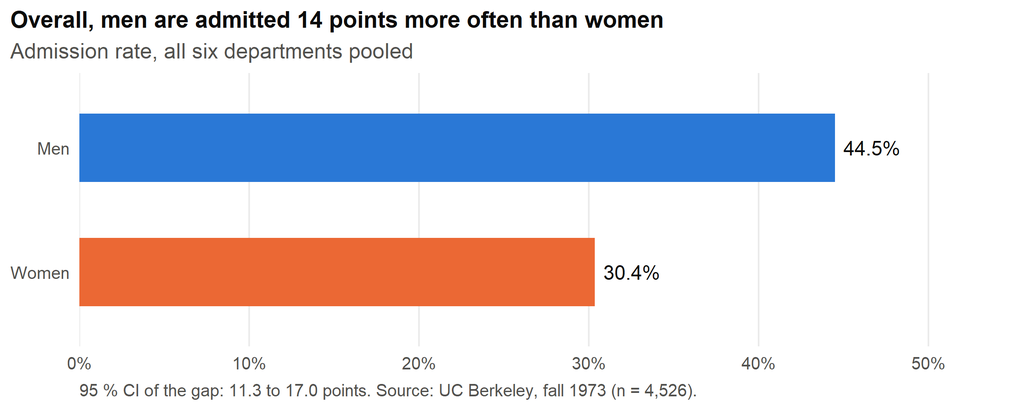

Figure 1

```r
overall$label <- LAB_GENDER[as.character(overall$gender)]
p1 <- ggplot(overall, aes(x = rate, y = reorder(label, rate), fill = gender)) +
  geom_col(width = 0.55) +
  geom_text(aes(label = pct(rate)), hjust = -0.15, colour = INK, size = 4) +
  scale_fill_manual(values = COL_GENDER, guide = "none") +
  scale_x_continuous(labels = scales::percent, limits = c(0, 0.55), expand = c(0, 0)) +
  labs(
    title = sprintf("Overall, men are admitted %.0f points more often than women",
                    100 * gap$gap),
    subtitle = "Admission rate, all six departments pooled",
    x = NULL, y = NULL,
    caption = sprintf("95 %% CI of the gap: %.1f to %.1f points. Source: UC Berkeley, fall 1973 (n = 4,526).",
                      100 * gap$conf_int[1], 100 * gap$conf_int[2])
  ) +
  theme_audit()
save_fig(p1, "01_overall_gap", height = 3.2)
```

## 2. Department by department, the gap reverses

```r
by_dept <- admission_rates(d, c("dept", "gender"))
wide <- reshape(by_dept[, c("dept", "gender", "applicants", "rate")],
                idvar = "dept", timevar = "gender", direction = "wide")
women_ahead <- sum(wide$rate.Female > wide$rate.Male)
knitr::kable(
  data.frame(Department = wide$dept,
             `Men applicants` = wide$applicants.Male, `Men rate` = pct(wide$rate.Male),
             `Women applicants` = wide$applicants.Female, `Women rate` = pct(wide$rate.Female),
             check.names = FALSE),
  format.args = list(big.mark = ",")
)
```

| Department | Men applicants | Men rate | Women applicants | Women rate |
| --- | --- | --- | --- | --- |
| A | 825 | 62.1% | 108 | 82.4% |
| B | 560 | 63.0% | 25 | 68.0% |
| C | 325 | 36.9% | 593 | 34.1% |
| D | 417 | 33.1% | 375 | 34.9% |
| E | 191 | 27.7% | 393 | 23.9% |
| F | 373 | 5.9% | 341 | 7.0% |

Women have the higher admission rate in **4 of 6 departments**. The pooled gap and the within-department picture point in opposite directions: this is **Simpson’s paradox**.

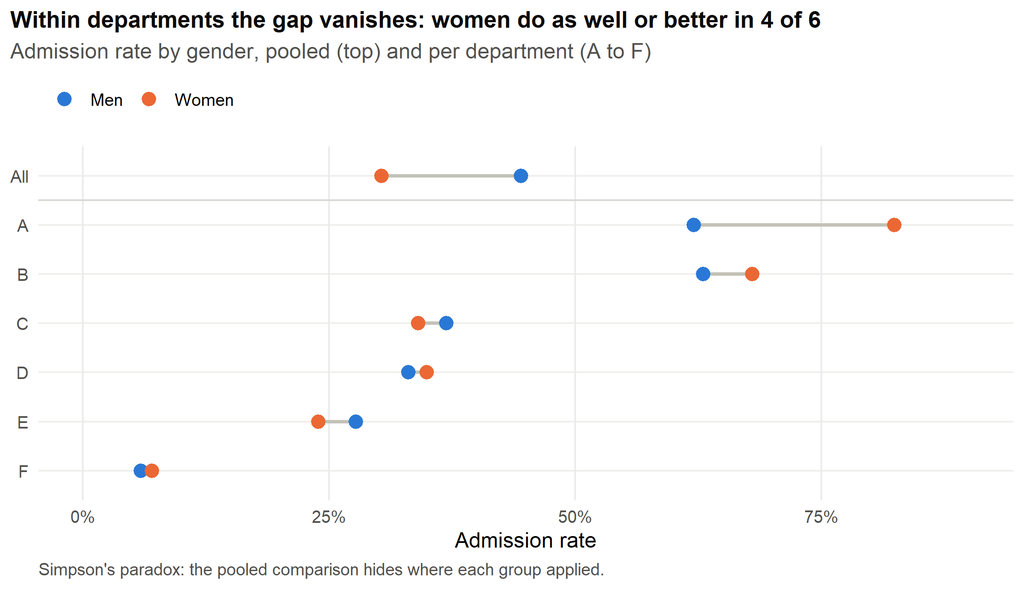

Figure 2

```r
seg <- data.frame(dept = wide$dept, from = wide$rate.Male, to = wide$rate.Female)
pooled <- data.frame(dept = "All", from = gap$rate_male, to = gap$rate_female)
seg <- rbind(pooled, seg)
seg$dept <- factor(seg$dept, levels = rev(c("All", LETTERS[1:6])))
pts <- rbind(
  data.frame(dept = seg$dept, gender = "Male", rate = seg$from),
  data.frame(dept = seg$dept, gender = "Female", rate = seg$to)
)
p2 <- ggplot() +
  geom_hline(yintercept = 6.5, colour = "#d9d8d4") +
  geom_segment(data = seg, aes(x = from, xend = to, y = dept, yend = dept),
               colour = "#c3c2b7", linewidth = 1) +
  geom_point(data = pts, aes(x = rate, y = dept, colour = gender), size = 3.2) +
  scale_colour_manual(values = COL_GENDER, labels = LAB_GENDER, breaks = c("Male", "Female"), name = NULL) +
  scale_x_continuous(labels = scales::percent, limits = c(0, 0.9)) +
  labs(
    title = sprintf("Within departments the gap vanishes: women do as well or better in %d of 6",
                    women_ahead),
    subtitle = "Admission rate by gender, pooled (top) and per department (A to F)",
    x = "Admission rate", y = NULL,
    caption = "Simpson's paradox: the pooled comparison hides where each group applied."
  ) +
  theme_audit() +
  theme(panel.grid.major.y = element_line(colour = "#f0efec"))
save_fig(p2, "02_simpson_by_department", height = 4.6)
```

## 3. Admission depends on the department, and strongly

*Does the chance of admission differ between departments (1 % level), ignoring gender?*

```r
cs <- admit_dept_chisq(d)
```

- **Test**: Pearson chi-square of independence, Admit x Dept: X² = 778.9, 5 df, p < 0.001. Independence is rejected at the 1 % level.
- **Conditions**: the rule applies to **expected** counts under H0, not observed ones. The smallest expected count is 226.5 and 100% of cells have an expected count of at least 5, so the chi-square approximation is valid. Observations are independent applications (one row per application).
- **Effect size**: Cramér’s V = 0.41, a strong association, not just a “significant” one.

**Which cells drive the dependence?** The coursework used `cor()` on the contingency table, which is meaningless here (two rows always give correlations of +1 or -1). The right tool is the **standardized residual** of each cell, (observed - expected) / its standard error: values beyond ±2 point to cells that depart clearly from independence, and the sign gives the direction.

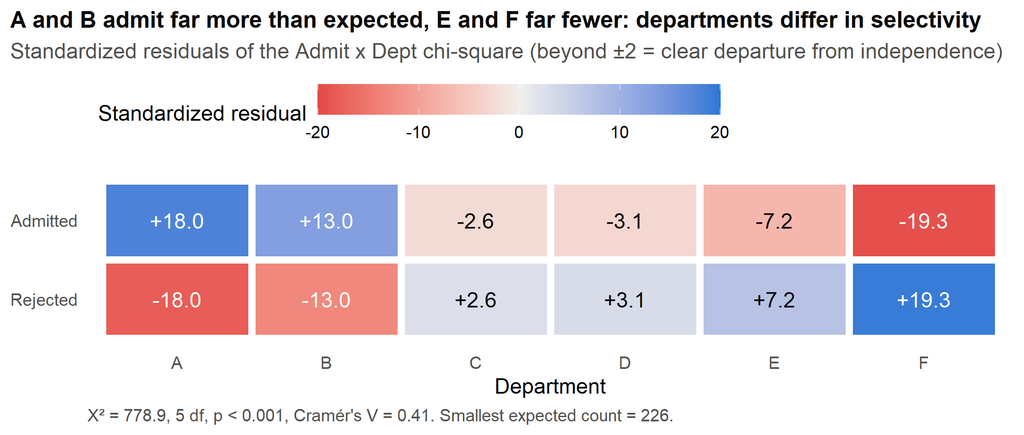

Figure 3

```r
res <- cs$residuals
res$admit <- factor(res$admit, levels = c("Rejected", "Admitted"))
lim <- ceiling(max(abs(res$std_residual)))
p3 <- ggplot(res, aes(x = dept, y = admit, fill = std_residual)) +
  geom_tile(colour = "white", linewidth = 2) +
  geom_text(aes(label = sprintf("%+.1f", std_residual),
                colour = abs(std_residual) > 10), size = 4.2, show.legend = FALSE) +
  scale_colour_manual(values = c(`TRUE` = "white", `FALSE` = INK)) +
  scale_fill_gradient2(low = "#e34948", mid = "#f0efec", high = "#2a78d6",
                       midpoint = 0, limits = c(-lim, lim),
                       name = "Standardized residual") +
  labs(
    title = "A and B admit far more than expected, E and F far fewer: departments differ in selectivity",
    subtitle = "Standardized residuals of the Admit x Dept chi-square (beyond ±2 = clear departure from independence)",
    x = "Department", y = NULL,
    caption = sprintf("X² = %.1f, %d df, p < 0.001, Cramér's V = %.2f. Smallest expected count = %.0f.",
                      cs$statistic, cs$df, cs$cramers_v, cs$min_expected)
  ) +
  theme_audit() +
  theme(panel.grid = element_blank(), legend.key.width = unit(1.6, "cm"))
save_fig(p3, "03_residuals_admit_dept", height = 3.4)
```

```r
adm <- res[res$admit == "Admitted", ]
adm$direction <- ifelse(adm$std_residual > 2, "More admissions than expected",
                 ifelse(adm$std_residual < -2, "More rejections than expected", "Close to independence"))
knitr::kable(adm[, c("dept", "observed", "expected", "std_residual", "direction")],
             digits = 1, row.names = FALSE,
             col.names = c("Department", "Admitted (observed)", "Admitted (expected)",
                           "Std. residual", "Contribution"))
```

| Department | Admitted (observed) | Admitted (expected) | Std. residual | Contribution |
| --- | --- | --- | --- | --- |
| A | 601 | 361.8 | 18.0 | More admissions than expected |
| B | 370 | 226.8 | 13.0 | More admissions than expected |
| C | 322 | 356.0 | -2.6 | More rejections than expected |
| D | 269 | 307.1 | -3.1 | More rejections than expected |
| E | 147 | 226.5 | -7.2 | More rejections than expected |
| F | 46 | 276.9 | -19.3 | More rejections than expected |

All six departments contribute: **A and B** pull towards admission, **C, D, E and F** towards rejection, with **F** (residual -19.3) and **A** (+18.0) the largest contributors.

## 4. Where people applied explains the pooled gap

```r
mix <- application_mix(d)
dept_rates <- admission_rates(d, "dept")
selective <- as.character(dept_rates$dept[dept_rates$rate < 0.5])
share_sel <- tapply(mix$share_of_gender[mix$dept %in% selective],
                    mix$gender[mix$dept %in% selective], sum)
```

Departments C, D, E, F admit fewer than half of their applicants. They received **93% of women’s applications** but only **49% of men’s**.

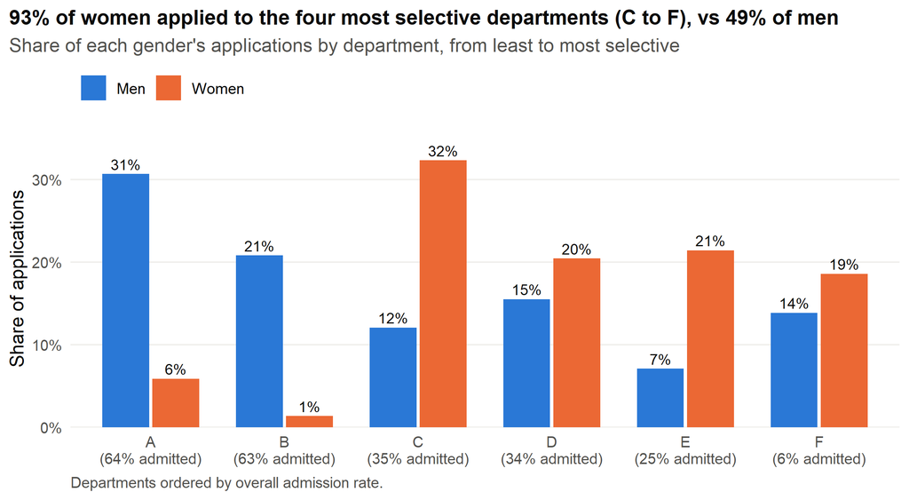

Figure 4

```r
mix$dept_lab <- factor(sprintf("%s\n(%s admitted)", mix$dept, pct(mix$dept_rate, 0)),
                       levels = unique(sprintf("%s\n(%s admitted)", dept_rates$dept[order(-dept_rates$rate)],
                                               pct(dept_rates$rate[order(-dept_rates$rate)], 0))))
p4 <- ggplot(mix, aes(x = dept_lab, y = share_of_gender, fill = gender)) +
  geom_col(position = position_dodge(width = 0.75), width = 0.7) +
  geom_text(aes(label = pct(share_of_gender, 0)), position = position_dodge(width = 0.75),
            vjust = -0.4, size = 3.3, colour = INK) +
  scale_fill_manual(values = COL_GENDER, labels = LAB_GENDER, name = NULL) +
  scale_y_continuous(labels = scales::percent, limits = c(0, 0.36), expand = c(0, 0)) +
  labs(
    title = sprintf("%s of women applied to the four most selective departments (C to F), vs %s of men",
                    pct(share_sel[["Female"]], 0), pct(share_sel[["Male"]], 0)),
    subtitle = "Share of each gender's applications by department, from least to most selective",
    x = NULL, y = "Share of applications",
    caption = "Departments ordered by overall admission rate."
  ) +
  theme_audit() +
  theme(panel.grid.major.x = element_blank(), panel.grid.major.y = element_line(colour = "#f0efec"))
save_fig(p4, "04_application_mix", height = 4.4)
```

## 5. Controlling for department: no evidence of bias against women

```r
cmh <- cmh_gender(d)
lg <- logit_gender_dept(d)
or <- lg$odds_ratios
or_f <- or[or$term == "genderFemale", ]
or$term <- c("Intercept (odds, men in A)", "Women vs men", paste("Dept", LETTERS[2:6], "vs A"))
knitr::kable(or, digits = c(0, 2, 2, 2, 4), row.names = FALSE,
             col.names = c("Term", "Odds ratio", "95 % CI low", "95 % CI high", "p-value"))
```

| Term | Odds ratio | 95 % CI low | 95 % CI high | p-value |
| --- | --- | --- | --- | --- |
| Intercept (odds, men in A) | 1.79 | 1.56 | 2.05 | 0.0000 |
| Women vs men | 1.11 | 0.94 | 1.29 | 0.2167 |
| Dept B vs A | 0.96 | 0.77 | 1.19 | 0.6928 |
| Dept C vs A | 0.28 | 0.23 | 0.35 | 0.0000 |
| Dept D vs A | 0.27 | 0.22 | 0.34 | 0.0000 |
| Dept E vs A | 0.18 | 0.14 | 0.22 | 0.0000 |
| Dept F vs A | 0.04 | 0.03 | 0.05 | 0.0000 |

- **Cochran-Mantel-Haenszel** (Admit x Gender, stratified by department): common odds ratio women vs men = **1.11** (95 % CI 0.94 to 1.30), p = 0.23.
- **Logistic regression** Admit ~ Gender + Dept: odds ratio women vs men = **1.11** (95 % CI 0.94 to 1.29), p = 0.22. The department odds ratios range from 0.04 to 0.96: the department applied to matters far more than gender.
- **Is the gender effect the same everywhere?** Adding a Gender x Dept interaction improves the fit (likelihood-ratio test p = 0.001). The heterogeneity comes mainly from department A, where women are admitted at a much higher rate than men. The common odds ratio is therefore an average, not a constant.

Once department is accounted for, the odds of admission for women are **not lower** than for men: the point estimate is slightly in their favour and the confidence interval includes 1.

## 6. What a decision-maker should take away

**Where the real issue is.** The 14-point pooled gap is not produced by committees treating women worse than men in the same department. It comes from two facts combined: departments differ hugely in selectivity (from about 6 % to 64 % admitted), and women applied mostly to the most selective ones. Auditing only the headline rate would have led to the wrong diagnosis and the wrong remedy.

**Questions to ask next.**

1. Why do the most demanded departments admit so few? Is it capacity (places, funding per student) or stricter criteria?
2. Why did women apply mostly to those departments? Field preferences, prior training, outreach, or perceived chances elsewhere?
3. Is funding allocated in proportion to demand? A department with many applicants and few places is a resource question, not only a selection question.
4. In department A, women are admitted much more often than men: is that explained by application quality, or does it need its own review?

**Limits.**

- **Observational, aggregated data**: no information on applicant qualifications (grades, test scores, references). The analysis rules out a department-level gender gap; it cannot rule out bias in how applicants were steered towards departments, or bias offset by stronger female applications.
- **Six departments only** (the largest ones), one year (1973), binary gender as recorded at the time.
- **Department labels are anonymised**, so the selectivity finding cannot be linked to specific fields.
- The common odds ratio hides heterogeneity between departments (interaction test above).